# Elections & Polls

We will use polling data organised by FiveThirtyEight for the 2016 presidential election. The data is included as part of the dslabs package. Once we load the data the first thing to do is to understand the data.

```r
library(dslabs)
library(dplyr) # for data manipulation
data(polls_us_election_2016)
?polls_us_election_2016
dim(polls_us_election_2016) #dimensions of the data (nxp)
```

```
[1] 4208   15
```

```r
str(polls_us_election_2016) #structure of the data
```

```
'data.frame':   4208 obs. of  15 variables:
 $ state           : Factor w/ 57 levels "Alabama","Alaska",..: 50 50 50 50 50 50 50 50 37 50 ...
 $ startdate       : Date, format: "2016-11-03" "2016-11-01" ...
 $ enddate         : Date, format: "2016-11-06" "2016-11-07" ...
 $ pollster        : Factor w/ 196 levels "ABC News/Washington Post",..: 1 63 81 194 65 55 18 113 195 76 ...
 $ grade           : Factor w/ 10 levels "D","C-","C","C+",..: 10 6 8 6 5 9 8 8 NA 8 ...
 $ samplesize      : int  2220 26574 2195 3677 16639 1295 1426 1282 8439 1107 ...
 $ population      : chr  "lv" "lv" "lv" "lv" ...
 $ rawpoll_clinton : num  47 38 42 45 47 ...
 $ rawpoll_trump   : num  43 35.7 39 41 43 ...
 $ rawpoll_johnson : num  4 5.46 6 5 3 3 5 6 6 7.1 ...
 $ rawpoll_mcmullin: num  NA NA NA NA NA NA NA NA NA NA ...
 $ adjpoll_clinton : num  45.2 43.3 42 45.7 46.8 ...
 $ adjpoll_trump   : num  41.7 41.2 38.8 40.9 42.3 ...
 $ adjpoll_johnson : num  4.63 5.18 6.84 6.07 3.73 ...
 $ adjpoll_mcmullin: num  NA NA NA NA NA NA NA NA NA NA ...
```

```r
summary(polls_us_election_2016) #summary statistics for numerical variables
```

```
            state        startdate             enddate
 U.S.          :1106   Min.   :2015-11-06   Min.   :2015-11-08
 Florida       : 148   1st Qu.:2016-08-10   1st Qu.:2016-08-21
 North Carolina: 125   Median :2016-09-23   Median :2016-09-30
 Pennsylvania  : 125   Mean   :2016-08-31   Mean   :2016-09-06
 Ohio          : 115   3rd Qu.:2016-10-20   3rd Qu.:2016-10-28
 New Hampshire : 112   Max.   :2016-11-06   Max.   :2016-11-07
 (Other)       :2477
                                     pollster        grade        samplesize
 Ipsos                                   : 919   A-     :1085   Min.   :   35.0
 Google Consumer Surveys                 : 743   B      :1011   1st Qu.:  447.5
 SurveyMonkey                            : 660   C-     : 693   Median :  772.0
 YouGov                                  : 130   C+     : 329   Mean   : 1148.2
 Rasmussen Reports/Pulse Opinion Research: 125   B+     : 204   3rd Qu.: 1236.5
 USC Dornsife/LA Times                   : 121   (Other): 457   Max.   :84292.0
 (Other)                                 :1510   NA's   : 429   NA's   :1
  population        rawpoll_clinton rawpoll_trump   rawpoll_johnson
 Length:4208        Min.   :11.04   Min.   : 4.00   Min.   : 0.000
 Class :character   1st Qu.:38.00   1st Qu.:35.00   1st Qu.: 5.400
 Mode  :character   Median :43.00   Median :40.00   Median : 7.000
                    Mean   :41.99   Mean   :39.83   Mean   : 7.382
                    3rd Qu.:46.20   3rd Qu.:45.00   3rd Qu.: 9.000
                    Max.   :88.00   Max.   :68.00   Max.   :25.000
                                                    NA's   :1409
 rawpoll_mcmullin adjpoll_clinton adjpoll_trump    adjpoll_johnson
 Min.   : 9.0     Min.   :17.06   Min.   : 4.373   Min.   :-3.668
 1st Qu.:22.5     1st Qu.:40.21   1st Qu.:38.429   1st Qu.: 3.145
 Median :25.0     Median :44.15   Median :42.765   Median : 4.384
 Mean   :24.0     Mean   :43.32   Mean   :42.674   Mean   : 4.660
 3rd Qu.:27.9     3rd Qu.:46.92   3rd Qu.:46.290   3rd Qu.: 5.756
 Max.   :31.0     Max.   :86.77   Max.   :72.433   Max.   :20.367
 NA's   :4178                                      NA's   :1409
 adjpoll_mcmullin
 Min.   :11.03
 1st Qu.:23.11
 Median :25.14
 Mean   :24.51
 3rd Qu.:27.98
 Max.   :31.57
 NA's   :4178
```

Looking at the data information from the R Documentation we see that we have results from national and state polls. We also see there is a grade assigned to each poll.

We see that p = 15 and n = 4208, and polls cover 08 Nov 2015 to 07 Nov 2016 (enddate) which is effectively the year prior to the election.

From the summary statistics we can see the presence of NAs. Let’s visualise them:

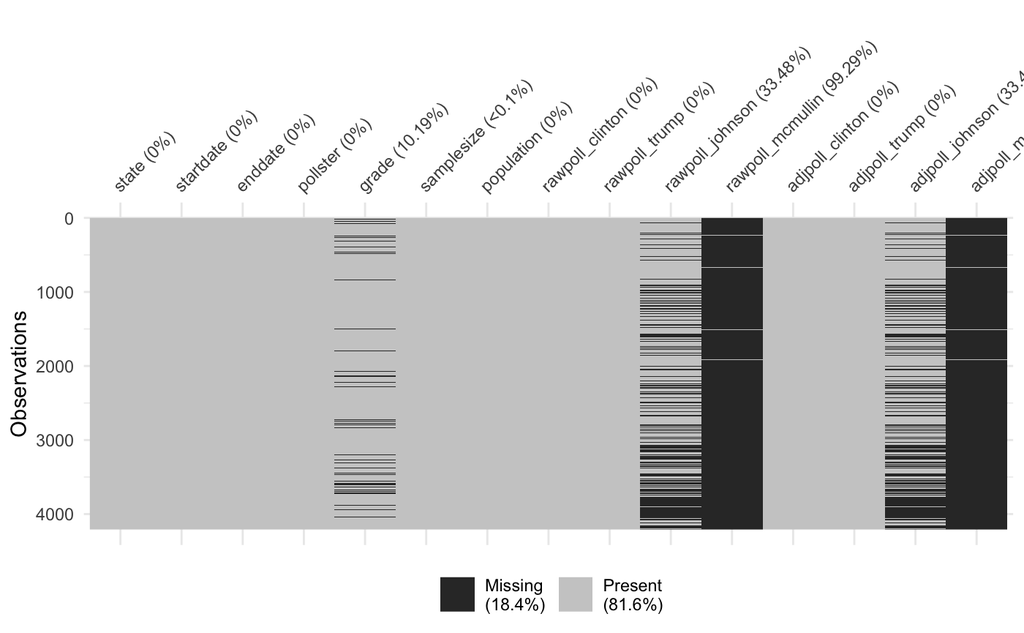

```r
#The simplest function for visualising missing data is the vis_miss() function within the visdat package
library(visdat)
vis_miss(polls_us_election_2016) #can also add cluster = TRUE argument to see the missing data in clusters
```

For the first example, we will filter the data to only include national polls conducted during the week before the election (ie from 31 October 2016 onwards). We will also remove polls FiveThirtyEight has deemed unreliable and graded with a “B” or less. Note that from the visualisation above, we see there are NAs present in grade. We will include those without a grade.

```r
dim(polls)
```

```
[1] 49 15
```

This filtration reduced our n to 49 across 15 variables.

For our ultimate prediction of election results, we are really interested in the spread (ie the difference between % poll results for each candidate). Since rawpoll results for Johnson and McMullin are largely NA, we will ignore them and assume only 2 candidates: Clinton vs Trump. We can designate Clinton’s proportion as p and Trump’s as 1-p. So we are interested in the spread: 2p-1

So let’s calculate the estimated spread for combined polls. We can then add this as a new column called “spread” to the “polls” we created above:

```r
polls <- polls %>%
  mutate(spread = rawpoll_clinton/100 - rawpoll_trump/100)
```

We now have 49 different estimates of the spread from 49 different polls. We assume that these estimates are a random variable with a probability distribution that is approximately normal. What this assumption means is that the expected value of the election night spread = difference = d = 2p-1, and the standard error is 2*sqrt(p(1-p)/n)

If this assumption holds, then we can construct a confidence interval based on the aggregate data. The estimated spread is now computed like this because now the sample size is the sum of all the sample sizes.

```r
#Estimating spread of aggregated polls. Spread = difference = d

d_hat <- polls %>%
  summarise(d_hat = sum(spread * samplesize)/sum(samplesize)) %>%
  pull(d_hat)
d_hat
```

```
[1] 0.01426264
```

Our estimated spread of the aggregate data is approximately 0.0143 or 1.43%. We can calculate the standard error of this next:

```r
p_hat <- (d_hat + 1)/2 #estimated proportion of Clinton obtained from d_hat = 2p-1

#standard error = 2*sqrt(p*(1-p)/n)
p_hat_se <- 2*sqrt(p_hat*(1-p_hat)/sum(polls$samplesize))

#Confidence Interval of standard error:
CI_p_hat_se <- qnorm(0.975)*p_hat_se #2-tailed normal distribution - more accurate than using 1.96 straight

CI_p_hat_se
```

| d_hat |
| --- |
| 0.006623057 |

So if we were going to use this data, we would report a spread of 1.43% +/- 0.66%.

When we look at the actual outcome on the election night we’d discover that the real spread was 2.1% which is outside of the 95% confidence interval (1.43% + 0.66% = 2.09%).

What happened?

To check we can look at the histogram of the spreads reported by the polls:

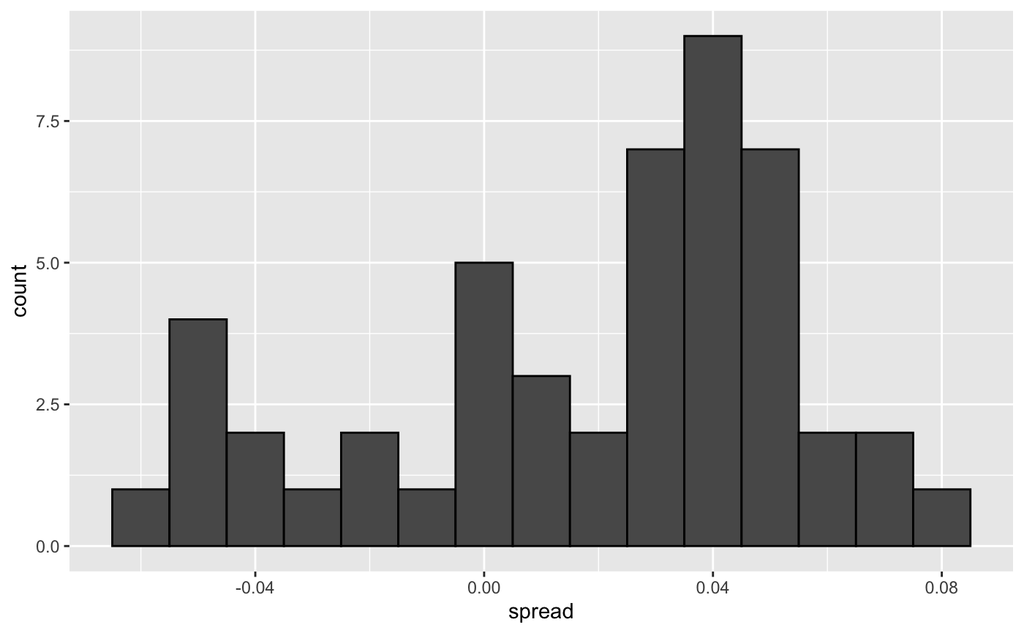

```r
# Histogram of reported spreads
polls %>%
  ggplot(aes(spread)) +
  geom_histogram(colour = "black", binwidth = 0.01)
```

From histogram, it is clear that the data is not Gaussian, and the standard error appears to be larger than 0.0066 we estimated. The theory is not quite working here.

One reason for this can be pollster bias.

Various pollsters are involved and some are taking several polls a week. We can look at the number of polls each pollsters took the last week leading up to the election:

```r
polls %>% group_by(pollster) %>% summarise(n())
```

| pollster | n() |
| --- | --- |
| ABC News/Washington Post | 7 |
| Angus Reid Global | 1 |
| CBS News/New York Times | 2 |
| Fox News/Anderson Robbins Research/Shaw & Company Research | 2 |
| IBD/TIPP | 8 |
| Insights West | 1 |
| Ipsos | 6 |
| Marist College | 1 |
| Monmouth University | 1 |
| Morning Consult | 1 |

[output cut: 5 more lines]

Lets look at the spreads by pollsters that polls frequently. Let’s filter for pollsters that polled at least 6 times, and then plot the spreads estimated by each pollster:

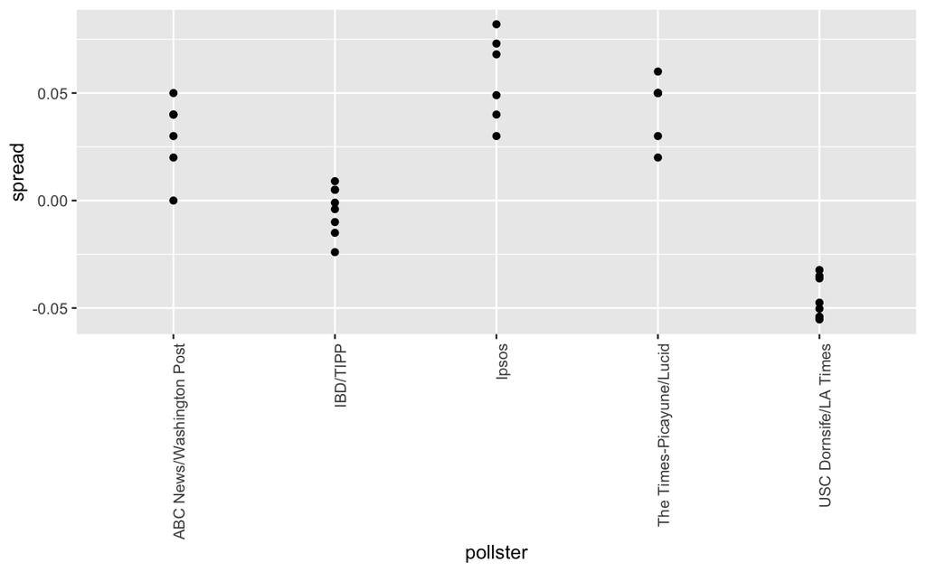

```r
polls %>% group_by(pollster) %>%
  filter(n() >= 6) %>%
  ggplot(aes(pollster, spread)) +
  geom_point() +
  theme(axis.text.x = element_text(angle = 90, hjust = 1))
```

This is unusual. Technically, all the pollsters should have the same expected value but clearly this is not the case. While Ipsos predicts a larger than 5% Clinton win, USC/LA Times predicts a 4% Trump win. FiveThirtyEight refers to these differences as “house effects”; we call them “pollster bias”.

We will instead develop a data-driven model now to produce a better estimate and a better confidence interval.

For each pollster lets collect their last reported result before the election:

| state | startdate | enddate | pollster | grade | samplesize | population | rawpoll_clinton | rawpoll_trump | rawpoll_johnson | rawpoll_mcmullin | adjpoll_clinton | adjpoll_trump | adjpoll_johnson | adjpoll_mcmullin | spread |
| --- | --- | --- | --- | --- | --- | --- | --- | --- | --- | --- | --- | --- | --- | --- | --- |
| U.S. | 2016-11-03 | 2016-11-06 | ABC News/Washington Post | A+ | 2220 | lv | 47.00 | 43.00 | 4.0 | NA | 45.20163 | 41.72430 | 4.626221 | NA | 0.0400 |
| U.S. | 2016-11-02 | 2016-11-06 | Ipsos | A- | 2195 | lv | 42.00 | 39.00 | 6.0 | NA | 42.02638 | 38.81620 | 6.844734 | NA | 0.0300 |
| U.S. | 2016-11-03 | 2016-11-06 | Fox News/Anderson Robbins Research/Shaw & Company Research | A | 1295 | lv | 48.00 | 44.00 | 3.0 | NA | 49.02208 | 43.95631 | 3.057876 | NA | 0.0400 |
| U.S. | 2016-11-02 | 2016-11-06 | CBS News/New York Times | A- | 1426 | lv | 45.00 | 41.00 | 5.0 | NA | 45.11649 | 40.92722 | 4.341786 | NA | 0.0400 |
| U.S. | 2016-11-03 | 2016-11-05 | NBC News/Wall Street Journal | A- | 1282 | lv | 44.00 | 40.00 | 6.0 | NA | 43.58576 | 40.77325 | 5.365788 | NA | 0.0400 |
| U.S. | 2016-11-04 | 2016-11-07 | IBD/TIPP | A- | 1107 | lv | 41.20 | 42.70 | 7.1 | NA | 42.92745 | 42.23545 | 6.316175 | NA | -0.0150 |
| U.S. | 2016-11-04 | 2016-11-06 | Selzer & Company | A+ | 799 | lv | 44.00 | 41.00 | 4.0 | NA | 44.21714 | 40.57082 | 4.068708 | NA | 0.0300 |
| U.S. | 2016-11-01 | 2016-11-04 | Angus Reid Global | A- | 1151 | lv | 48.00 | 44.00 | 6.0 | NA | 47.57171 | 43.68125 | 5.556625 | NA | 0.0400 |
| U.S. | 2016-11-03 | 2016-11-06 | Monmouth University | A+ | 748 | lv | 50.00 | 44.00 | 4.0 | NA | 48.86765 | 43.39600 | 4.838600 | NA | 0.0600 |
| U.S. | 2016-11-01 | 2016-11-03 | Marist College | A | 940 | lv | 44.00 | 43.00 | 6.0 | NA | 42.83406 | 43.43819 | 4.780429 | NA | 0.0100 |

[output cut: 5 more lines]

Let’s then look at the histogram of the spread for these 15 pollsters:

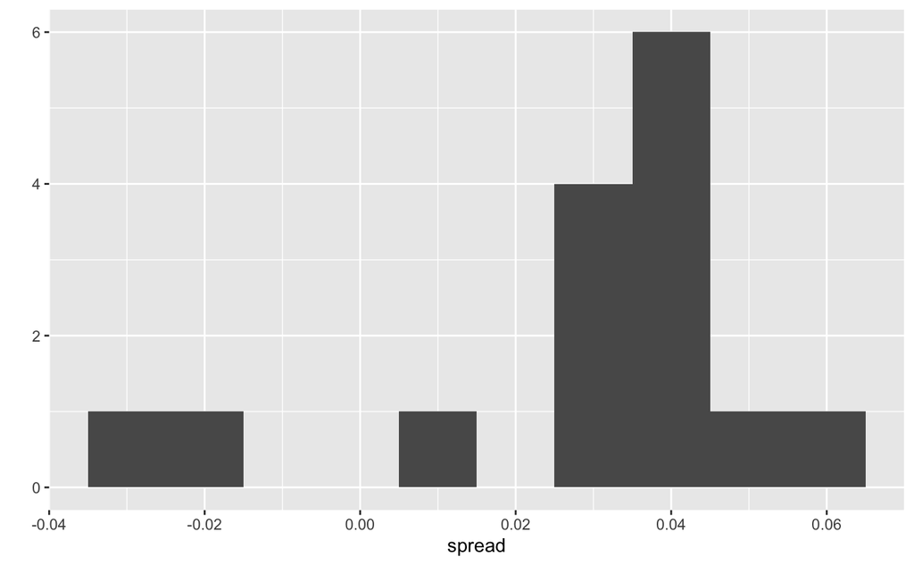

```r
qplot(spread,
      data = one_poll_per_pollster,
      binwidth = 0.01)
```

Now we will model this spread directly.

The expected value of the spread is still d = 2p-1. However, because we are drawing from sample poll results from all possible pollsters and not discreet in 0s (Republicans) and 1s (Democrats), we are looking at continuous numbers between -1 and 1. This means, the standard deviation is no longer sqrt(p*(1-p)). This is because, the standard error now also includes the pollster-to-pollster variability, and not just voter sampling variability. So, now, the standard deviation is an unknown parameter, sigma.

In summary we have two unknown parameters now: 1. The expected value d = 2p-1 2. standard deviation, sigma.

Our task is to estimate d.

We don’t know sigma but we can estimate sample standard deviation, s. The sd() function computes the sample standard deviation, s:

```r
sd(one_poll_per_pollster$spread)
```

```
[1] 0.02419369
```

We are now ready to form a new confidence interval based on our new data-driven model. We simply use Central Limit Theorem and create CI:

```r
results <- one_poll_per_pollster %>%
  summarise(avg = mean(spread),
            se = sd(spread) / sqrt(length(spread))) %>%
  mutate(lower = avg - qnorm(0.975) * se,
         upper = avg + qnorm(0.975) * se)
round(results * 100, 1)
```

| avg | se | lower | upper |
| --- | --- | --- | --- |
| 2.9 | 0.6 | 1.7 | 4.1 |

We get an average of 2.9% with an se of 0.6% and a CI from 1.7% to 4.1%. This interval includes the election night result of 2.1%. The CI is also small enough not to include 0%, so we would have been quite confident Clinton would win the popular vote.

However, we are not ready to declare a probability of Clinton winning the popular vote. This is because in our model so far d has been a fixed parameter, so we can’t talk about probabilities.

We have to utilise Bayesian statistics.

For the 2016 election, FiveThirtyEight gave Clinton an 81.4% chance of winning the popular vote. To do this they used the Bayesian approach we described.

We are going to assume a hierarchical model. This means we will assume: –> d is normally distributed around mu with a standard deviation of tau.(Prior distribution). This describes our best guess had we not seen any polling data. –> X_bar, conditional on d being known, is normally distributed around d with a standard deviation of sigma. (Sampling distribution). This describes randomness due to sampling and the pollster effect.

This is referred to as a hierarchical model because we need to know d, the first model, in order to model X_bar, the second level. In Bayesian framework, the first level is called Prior Distribution and the second Sampling Distribution.

For the best guess - before any poll data is available - we can use data sources other than polling data. A popular approach is to use what pollsters call fundamentals, which are based on properties about the current economy that historically appear to have an effect in favour or against the incumbent party. But we will not use this here.

Instead we will use: –> mu = 0, which is interpreted as a model that simply does not provide any information on who will win. –> tau = 0.035 which is derived from recent historical data that shows the winner of popular vote has an average spread of about 3.5%.

Now we can use the formulas for the posterior distribution for the parameter d: the probability of d>0 given the observed poll data:

```r
mu <- 0
tau <- 0.035
sigma <- results$se
Y <- results$avg
B <- sigma^2 / (sigma^2 + tau^2)

posterior_mean <- B*mu + (1-B)*Y
posterior_se <- sqrt(1/(1/sigma^2 + 1/tau^2))

posterior_mean
```

```
[1] 0.02808534
```

```r
posterior_se
```

```
[1] 0.006149604
```

To make a probability statement we use the fact that the posterior distribution is also normal. So one thing we can do is report what is called a credible interval, ie. 95% confidence interval. Note that this interval is still random.

```r
posterior_mean + c(-qnorm(.975), qnorm(.975)) * posterior_se
```

```
[1] 0.01603234 0.04013834
```

So the interval goes from 1.6% to 4.01. What is interesting to report, however, is the probability of d > 0 given our estimate [Pr(d>0 | X_bar)].

```r
1-pnorm(0, posterior_mean, posterior_se)
```

```
[1] 0.9999975
```

This says 99.99% sure Clinton will win the popular vote, which seems overconfident. Also it is not in agreement with FiveThirtyEight’s 81.4%. What explains the difference?

After elections are over, one can look at the difference between pollster predictions and actual result. An important observation that our model does not take into account is that it is common to see a general bias that affects many pollsters in the same way making the observed data correlated. There is no good explanation for this, but we do observe it in historical data: in one election, the average of polls favors Democrats by 2%, then in the following election they favor Republicans by 1%, then in the next election there is no bias, then in the following one Republicans are favored by 3%, and so on. In 2016, the polls were biased in favor of the Democrats by 1-2%.

Although we know this bias term affects our polls, we have no way of knowing what this bias is until election night. So we can’t correct our polls accordingly. What we can do is include a term in our model that accounts for this variability.

To understand what new term(s) to introduce into our model lets recap what our model is.

Suppose we are collecting data from one pollster only and we assume there is no general bias.

```r
set.seed(3)
J <- 6
N <- 2000
d <- 0.021
p <- (d+1)/2
X <- d + rnorm(J, mean = 0, 2*sqrt(p*(1-p)/N))
```

To simulate the data we now have to loop through the pollsters:

```r
I <- 5
J <- 6
N <- 2000
X <- sapply(1:I, function(i){
  d + rnorm(J, mean = 0, 2*sqrt(p*(1-p)/N))
})
```

Lets now compare this simulated data to the actual data:

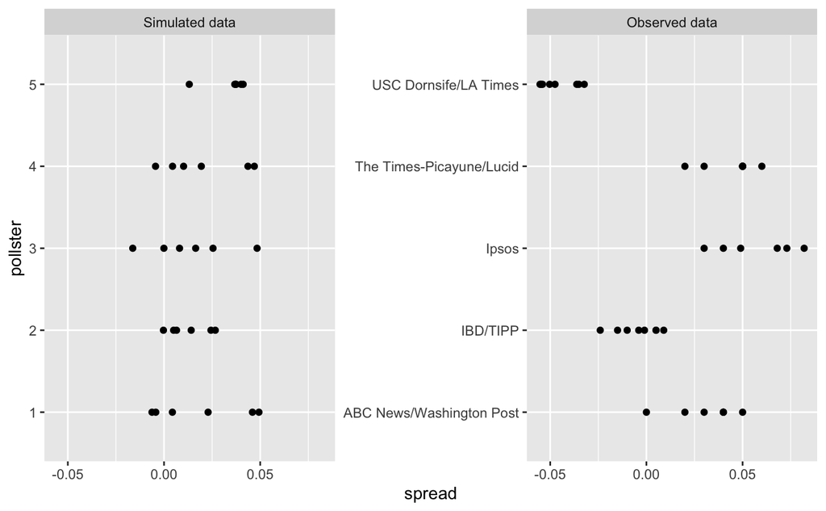

```r
polls %>% group_by(pollster) %>%
  filter(n() >= 6) %>%
  ungroup() %>%
  select(pollster, spread) %>%
  mutate(type = "Observed data", pollster = as.character(pollster)) %>%
  bind_rows(tibble(spread = as.vector(X) ,
                      pollster = rep(as.character(1:I), each=J),
                      type = "Simulated data")) %>%
  mutate(type = factor(type, levels = c("Simulated data", "Observed data"))) %>%
  ggplot(aes(pollster, spread)) +
  geom_point() +
  coord_flip() +
  facet_wrap( ~ type, scales = "free_y")
```

The model above does not seem to capture the features of the actual data nor account for pollster-to-pollster variability. In the simulated data all pollsters seem to agree on the expected outcome which is not the case in the real world data.

To fix this we add a new term for the pollster effect, h_i, to represent the bias of ith pollster. The model now becomes:

$$X_{i,j} = d + h_i + \varepsilon_{i,j}$$

To simulate data from a specific pollster, we now need to draw an h_i and then add the errors. Here is how to do it for one pollster. We assume standard deviation of h is 0.025.

```r
#Model with pollster bias (house effect)
I <- 5
J <- 6
N <- 2000
d <- 0.021
p <- (d+1)/2
h <- rnorm(I, mean = 0, sd = 0.025)
X <- sapply(1:I, function(i){
  d + h[i] + rnorm(J, mean = 0, 2*sqrt(p*(1-p)/N))
})
```

We can compare the simulated data to actual data again:

```r
data.frame(Spread = as.vector(X) , Pollster = as.factor(rep(1:I, each=J))) %>%
  ggplot(aes(Pollster, Spread)) +
  geom_point() +
  scale_y_continuous(limit = c(-0.056, 0.092)) +
  coord_flip()
```

[output not shown]

Note that h_i is common to all observed spreads from a specific pollsters. h_i only differs among the pollsters, which explains why we can see the groups of points shift from pollster to pollster.

In the above model we assumed the average pollster bias is 0 when we set the mean = 0 for h. This effectively assumes that for every pollster biased in favour of one party, there is another pollster in favour of the other party, with a standard deviation assumed to be 0.025.

However, historically we see that every election has a general bias affecting all polls. We can observe this with the 2016 data, but if we collect historical data, we see that the average of polls misses by more than models like the one above predict. To see this, we would take the average of polls for each election year and compare it to the actual value. If we did this, we would see a difference with a standard deviation of between 2-3%. To incorporate this into the model, we can add another term, b, to account for this variability:

$$X_{i,j} = d + b + h_i +
\varepsilon_{i,j}$$

Here b is a random variable that accounts for the election-to-election variability. This random variable changes from election to election, but for any given election, it is the same for all pollsters and polls within on election. This is why it does not have indexes.

This implies that all random variables X_ij for an election year are correlated since they all have b in common.

One way to interpret b is as the difference between the average of all polls from all pollsters and the actual results of the election. Because we don’t know the actual result until after the election, we can’t estimate b until after the election. However, we can estimate b from previous elections and study the distribution of these values.

Based on this approach we assume that, across election years, b has expected value 0 and the standard error is about 0.025.

An implication of adding this term to the model is that the standard deviation for X_ij is actually higher than what we earlier called sigma, which combines the pollster variability and sample variability, and was estimated with:

```r
sd(one_poll_per_pollster$spread)
```

This estimate does not include the variability introduced by b. we have to add the general bias term.

Note that now the sample average is

$$\bar{X} = d + b +
\frac{1}{N}\sum_{i=1}^N X_i$$

which implies that the standard deviation of X_bar is:

$$\sqrt{\sigma^2/N + \sigma_b^2}$$
Since the same b is in every measurement, the average does not reduce the variability introduced by the b term. This is an important point: it does not matter how many polls you take, this bias does not get reduced.

If we redo the Bayesian calculation taking this variability into account, we get a result much closer to FiveThirtyEight’s:

```r
mu <- 0
tau <- 0.035
sigma <- sqrt(results$se^2 + 0.025^2) #this is the st.dev. of X_bar
Y <- results$avg
B <- sigma^2 / (sigma^2 + tau^2)

posterior_mean <- B*mu + (1-B)*Y
posterior_se <- sqrt(1/ (1/sigma^2 + 1/tau^2))

1 - pnorm(q = 0, mean = posterior_mean, sd = posterior_se)
```

```
[1] 0.8174373
```

Note that sigma includes .025^2. That is the general bias variability. Once we do this we get a prob of Clinton winning the popular vote of 81.7%, much lower than the 99.99% we got previously.